# Verticillatae — provisional clades and elevations

Rooted on lachnoglossa. The tree search and bootstrap are incomplete. VC001–VC012 identify a nested review scaffold frozen from the stricter snapshot; they are not species names or claims of support. Tip IDs show the most specific selected group. Unassigned tips are outside this initial scaffold. Excluded tips remain visible as historical observations.

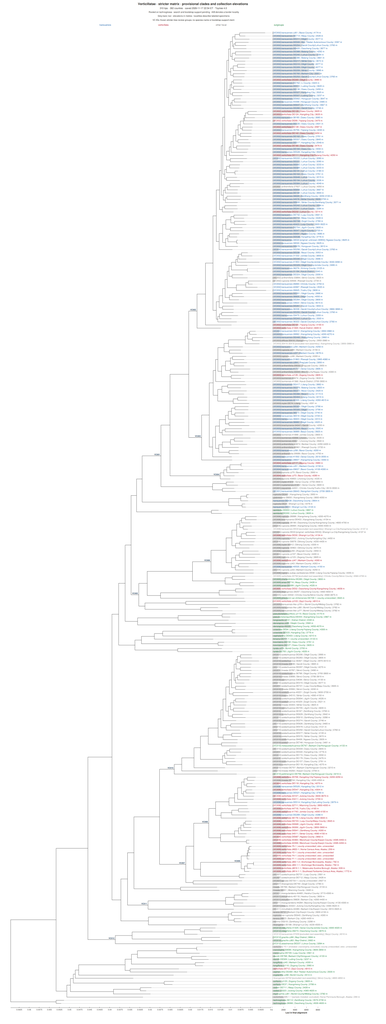

**Clade registry: 12 persistent IDs and nested memberships**

Initial memberships and source-tree checksum are frozen in clade-registry.json. IDs are never recycled or renumbered. Names require review of geography, images, specimens, descriptions and types. Counts and compositions below include historical excluded tips; they summarize original labels, not proposed diagnoses.

| ID | Parent | Review description | Initial tips | Original identifications | Monophyletic in this displayed snapshot | Taxonomic/support status |
| --- | --- | --- | --- | --- | --- | --- |
| VC001 |  | Broad mixed assemblage A | 147 | 30416: 1; anthemifolia: 7; bomiensis: 5; brachycrania: 1; diffusa: 1; kansuensis: 108; nyalamensis: 1; roylei: 2; rupicola: 5; unknown: 1; verticillata: 14; zayuensis: 1 | yes | pending; not a delimited species |
| VC002 | VC001 | Assemblage A, subgroup 1 | 95 | anthemifolia: 2; kansuensis: 80; rupicola: 1; unknown: 1; verticillata: 11 | yes | pending; not a delimited species |
| VC003 | VC001 | Assemblage A, subgroup 2 | 42 | 30416: 1; anthemifolia: 5; bomiensis: 5; brachycrania: 1; diffusa: 1; kansuensis: 25; roylei: 1; rupicola: 2; verticillata: 1 | yes | pending; not a delimited species |
| VC004 | VC001 | Assemblage A, basal subgroup | 6 | kansuensis: 2; rupicola: 2; verticillata: 2 | yes | pending; not a delimited species |
| VC005 |  | Mixed assemblage B | 31 | anas: 2; brachycrania: 1; cheilanthifolia: 1; kansuensis: 5; likiangensis: 1; pheulpinii: 1; roylei: 2; rupicola: 12; verticillata: 6 | yes | pending; not a delimited species |
| VC006 | VC005 | Assemblage B, internal subgroup | 19 | brachycrania: 1; kansuensis: 2; roylei: 1; rupicola: 12; verticillata: 3 | yes | pending; not a delimited species |
| VC007 |  | Mixed assemblage C | 35 | kansuensis: 4; likiangensis: 1; lineata: 1; spicata: 1; szetschuanica: 2; verticillata: 26 | yes | pending; not a delimited species |
| VC008 | VC007 | Assemblage C, subgroup 1 | 22 | kansuensis: 4; lineata: 1; verticillata: 17 | yes | pending; not a delimited species |
| VC009 | VC007 | Assemblage C, subgroup 2 | 9 | verticillata: 9 | yes | pending; not a delimited species |
| VC010 |  | Mixed assemblage D | 39 | lineata: 8; metaszetschuanica: 1; petitmenginii: 1; szetschuanica: 29 | yes | pending; not a delimited species |
| VC011 |  | Small allied assemblage E | 6 | lineata: 1; minutilabris: 3; triangularidens: 2 | yes | pending; not a delimited species |
| VC012 |  | External allied assemblage F | 6 | alaschanica: 1; gracilis: 2; integrifolia: 2; kansuensis: 1 | yes | pending; not a delimited species |

**All 310 historical tips: clades, locus counts, elevations and sources**

Counts refer to p20-n40-310tips. Elevations describe the labeled specimen, including any recorded range. The origin of mislabeled DNA remains unresolved. Y1–Y5 elevations are unrecorded pending collection records; KY/YY fieldnote accessions were not equated with these Y labels.

| Historical sample | Original identification | Nested clade path | Loci | County / region | Elevation (m) | Elevation status | Review / exclusion | Elevation source |
| --- | --- | --- | --- | --- | --- | --- | --- | --- |
| 30416-30416 | 30416 | VC001 > VC003 | 26 | Xiangcheng County | 3950-3980 | recorded_range | Excluded by user 2026-11-18: very low data (26 loci in current stricter matrix); likely technical replicate of diffusa-30416, which is retained as the representative. Replication is a proposed interpr… | [record](https://www.hengduan-biodiversity.net/fieldnotes/specimens/search/specimen_detail.zpt?specimen_id=15261) |
| alaschanica-DE237 | alaschanica | VC012 | 275 | Luhuo County | 3284 | recorded_value |  | record |
| anas-DE699 | anas | VC005 | 3077 | Jigzhi County | 4026 | recorded_value |  | record |
| anas-DE716 | anas | VC005 | 3130 | Maqu County | 3428 | recorded_value |  | record |
| anthemifolia-27837 | anthemifolia | VC001 > VC002 | 1413 | Luhuo County | 4050 | recorded_value |  | [record](https://www.hengduan-biodiversity.net/fieldnotes/specimens/search/specimen_detail.zpt?specimen_id=723) |
| anthemifolia-29532 | anthemifolia | VC001 > VC003 | 5335 | Zhag'yab County | 3950 | recorded_value |  | [record](https://www.hengduan-biodiversity.net/fieldnotes/specimens/search/specimen_detail.zpt?specimen_id=5384) |
| anthemifolia-29589 | anthemifolia | VC001 > VC003 | 3079 | Baxoi County | 4750 | recorded_value |  | [record](https://www.hengduan-biodiversity.net/fieldnotes/specimens/search/specimen_detail.zpt?specimen_id=5441) |
| anthemifolia-30000 | anthemifolia | VC001 > VC003 | 6251 | Biru County/Nagqu County | 4300 | recorded_value |  | [record](https://www.hengduan-biodiversity.net/fieldnotes/specimens/search/specimen_detail.zpt?specimen_id=5853) |
| anthemifolia-33894 | anthemifolia | VC001 > VC002 | 814 | Sêrxü County | 3920 | recorded_value |  | [record](https://www.hengduan-biodiversity.net/fieldnotes/specimens/search/specimen_detail.zpt?specimen_id=20552) |
| anthemifolia-40874 | anthemifolia | VC001 > VC003 | 3925 | Banbar County | 4350-4400 | recorded_range |  | [record](https://www.hengduan-biodiversity.net/fieldnotes/specimens/search/specimen_detail.zpt?specimen_id=64442) |
| anthemifolia-40961 | anthemifolia | VC001 > VC003 | 4048 | Riwoqê County | 3735 | recorded_value |  | [record](https://www.hengduan-biodiversity.net/fieldnotes/specimens/search/specimen_detail.zpt?specimen_id=64529) |
| axillaris-DE37 | axillaris | unassigned | 1521 | Xiangcheng County | 3799 | recorded_value |  | record |
| axillaris-JJ125 | axillaris | unassigned | 1665 | Zogang County | 3805 | recorded_value |  | record |
| binaria-DE771-1 | binaria | unassigned | 2547 |  | 4133 | recorded_value |  | record |
| bomiensis-40674 | bomiensis | VC001 > VC003 | 3721 | Zogang County | 3630 | recorded_value |  | [record](https://www.hengduan-biodiversity.net/fieldnotes/specimens/search/specimen_detail.zpt?specimen_id=64240) |
| bomiensis-40831 | bomiensis | VC001 > VC003 | 4302 | Lhorong County | 3940 | recorded_value |  | [record](https://www.hengduan-biodiversity.net/fieldnotes/specimens/search/specimen_detail.zpt?specimen_id=64399) |
| bomiensis-40898 | bomiensis | VC001 > VC003 | 6003 | Lhorong County | 4035 | recorded_value |  | [record](https://www.hengduan-biodiversity.net/fieldnotes/specimens/search/specimen_detail.zpt?specimen_id=64466) |
| bomiensis-41366 | bomiensis | VC001 > VC003 | 101 | Karub District | 3700-3900 | recorded_range |  | [record](https://www.hengduan-biodiversity.net/fieldnotes/specimens/search/specimen_detail.zpt?specimen_id=64935) |
| bomiensis-41898 | bomiensis | VC001 > VC003 | 1549 | Jomda County | 3900 | recorded_value |  | [record](https://www.hengduan-biodiversity.net/fieldnotes/specimens/search/specimen_detail.zpt?specimen_id=65467) |
| brachycrania-34047 | brachycrania | VC001 > VC003 | 6378 | Garzê County | 4200 | recorded_value |  | [record](https://www.hengduan-biodiversity.net/fieldnotes/specimens/search/specimen_detail.zpt?specimen_id=20753) |
| brachycrania-DE453 | brachycrania | VC005 > VC006 | 2252 | Xiangcheng County | 4154 | recorded_value |  | record |
| brevilabris-DE127 | brevilabris | unassigned | 2672 | Dawu County | 3605 | recorded_value |  | record |
| brevilabris-DE158 | brevilabris | unassigned | 2659 | Dawu County | 3761 | recorded_value |  | record |
| cephalantha-DE403 | cephalantha | unassigned | 1954 | Litang County | 4210 | recorded_value |  | record |
| cephalantha-DE480 | cephalantha | unassigned | 1352 | Muli Tibetan Autonomous County | 3500 | recorded_value |  | record |
| cheilanthifolia-DE285 | cheilanthifolia | VC005 | 2664 | Dêgê County | 3800 | recorded_value |  | record |
| cranolopha-30698 | cranolopha | unassigned | 2223 | Xiangcheng County | 3600-3850 | recorded_range |  | [record](https://www.hengduan-biodiversity.net/fieldnotes/specimens/search/specimen_detail.zpt?specimen_id=15536) |
| cranolopha-DE729 | cranolopha | unassigned | 1138 | Luqu County | 3561 | recorded_value |  | record |
| cryptantha-JJ98 | cryptantha | unassigned | 1837 | Bomê County | 3514 | recorded_value |  | record |
| davidii-DE509 | davidii | unassigned | 1189 | Luding County | 3237 | recorded_value |  | record |

[output cut: 280 more lines]